# Email Spam Classifier

This project builds a binary email spam classifier using the [SpamAssassin public corpus](https://spamassassin.apache.org/old/publiccorpus/), a dataset of 8,348 labeled emails collected in the early 2000s (0 = legitimate, 1 = spam). The analysis follows a two-stage arc: first, a simple baseline model built from word-indicator features; then an improved model with hand-engineered structural features, cross-validated and evaluated in full.

## 1. Setup

```python
import numpy as np
import pandas as pd
import zipfile
import warnings
warnings.filterwarnings('ignore')

import matplotlib.pyplot as plt
import seaborn as sns
from sklearn.model_selection import train_test_split
from sklearn.linear_model import LogisticRegression
from sklearn.metrics import accuracy_score, roc_curve, confusion_matrix

from utils import *

plt.rcParams['figure.figsize'] = (10, 6)
sns.set(style='whitegrid', color_codes=True, font_scale=1.3)
```

## 2. Data Loading & Overview

The dataset ships as a zip archive containing a labeled training set and an unlabeled test set. Six emails in the training set have missing subjects, filled with empty strings below.

```python
with zipfile.ZipFile('data/spam_ham_data.zip') as z:
    with z.open('train.csv') as f:
        original_data = pd.read_csv(f)
    with z.open('test.csv') as f:
        test_data = pd.read_csv(f)

original_data = original_data.fillna('')
test_data = test_data.fillna('')

print(f'Training set: {original_data.shape[0]:,} emails, {original_data["spam"].mean():.1%} spam')
original_data.head()
```

```
Training set: 8,348 emails, 25.6% spam
```

|  | id | subject | email | spam |
| --- | --- | --- | --- | --- |
| 0 | 0 | Subject: A&L Daily to be auctioned in bankrupt... | URL: http://boingboing.net/#85534171\n Date: N... | 0 |
| 1 | 1 | Subject: Wired: "Stronger ties between ISPs an... | URL: http://scriptingnews.userland.com/backiss... | 0 |
| 2 | 2 | Subject: It's just too small ... | <HTML>\n <HEAD>\n </HEAD>\n <BODY>\n <FONT SIZ... | 1 |
| 3 | 3 | Subject: liberal defnitions\n | Depends on how much over spending vs. how much... | 0 |
| 4 | 4 | Subject: RE: [ILUG] Newbie seeks advice - Suse... | hehe sorry but if you hit caps lock twice the ... | 0 |

The dataset is split 90/10 into training and validation sets. The random seed is fixed at 42 throughout.

```python
train, val = train_test_split(original_data, test_size=0.1, random_state=42)
train = train.reset_index(drop=True)
val   = val.reset_index(drop=True)
print(f'Train: {len(train):,}  |  Val: {len(val):,}')
```

```
Train: 7,513  |  Val: 835
```

## 3. Exploratory Data Analysis

### 3.1 Spam vs. Legitimate Email at a Glance

**Comparing the first legitimate and first spam email in the dataset reveals an immediate structural difference.** The legitimate email reads like a plain-text news digest — normal prose, readable URLs, no markup. The spam email is pure HTML: inline font tags, obfuscated character escapes (e.g., `3d"` for `="`), and a suspicious IP-address link with no domain name. This suggests that structural signals — the presence of HTML, suspicious formatting — may be as informative as the words themselves.

```python
first_ham  = original_data.loc[original_data['spam'] == 0, 'email'].iloc[0]
first_spam = original_data.loc[original_data['spam'] == 1, 'email'].iloc[0]

print('=== LEGITIMATE EMAIL (first 600 chars) ===')
print(first_ham[:600])
print('\n=== SPAM EMAIL (first 600 chars) ===')
print(first_spam[:600])
```

```
=== LEGITIMATE EMAIL (first 600 chars) ===
URL: http://boingboing.net/#85534171
 Date: Not supplied

 Arts and Letters Daily, a wonderful and dense blog, has folded up its tent due
 to the bankruptcy of its parent company. A&L Daily will be auctioned off by the
 receivers. Link[1] Discuss[2] (_Thanks, Misha!_)

 [1] http://www.aldaily.com/
 [2] http://www.quicktopic.com/boing/H/ZLfTeRjnD6Jf




=== SPAM EMAIL (first 600 chars) ===
<HTML>
 <HEAD>
 </HEAD>
 <BODY>
 <FONT SIZE=3D"4"><B> A man endowed with a 7-8" hammer is simply<br>
  better equipped than a man with a 5-6"hammer. <BR>
 <BR>Would you rather have<br>more than enough to get the job done or fall =
 short. It's totally up<br>to you. Our Methods are guaranteed to increase y=
 our size by 1-3"<br> <A HREF=3D"http://209.163.187.47/cgi-bin/index.php?10=
 004">Come in here and see how</A>
 </BODY>
 </HTML>
```

### 3.2 Word Frequency by Class

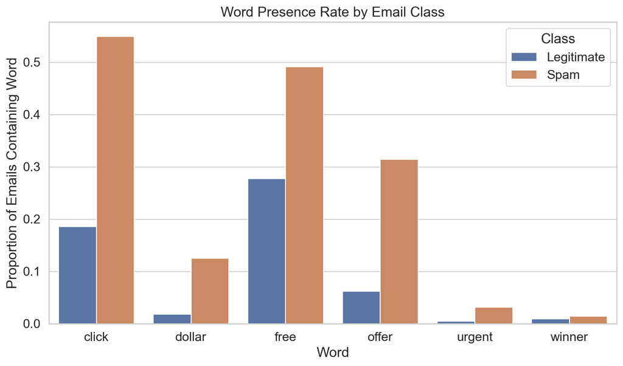

Proportion of emails containing each word, broken down by class.

```python
words_to_check = ['free', 'click', 'winner', 'offer', 'dollar', 'urgent']
train_lower = train.copy()
train_lower['email'] = train_lower['email'].str.lower()

word_array = words_in_texts(words_to_check, train_lower['email'])
word_df = pd.DataFrame(word_array, columns=words_to_check)
word_df['type'] = train['spam'].map({0: 'Legitimate', 1: 'Spam'})

grouped = word_df.melt(id_vars='type').groupby(['type', 'variable'])['value'].mean().reset_index()

sns.barplot(data=grouped, x='variable', y='value', hue='type')
plt.title('Word Presence Rate by Email Class')
plt.xlabel('Word')
plt.ylabel('Proportion of Emails Containing Word')
plt.legend(title='Class')
plt.tight_layout()
plt.show()
```

## 4. Feature Engineering

### 4.1 Word Indicator Features

```python
# Demonstrate words_in_texts
demo = words_in_texts(['hello', 'world'], pd.Series(['hello there', 'hello world', 'goodbye']))
pd.DataFrame(demo, columns=['hello', 'world'])
```

|  | hello | world |
| --- | --- | --- |
| 0 | 1 | 0 |
| 1 | 1 | 1 |
| 2 | 0 | 0 |

### 4.2 Structural & Lexical Features

**Word presence alone misses a lot of signal.** A richer set of features was designed to capture structural properties of emails that correlate with spam:

| Feature | Description |
| --- | --- |
| `has_html` | 1 if the email body contains any HTML tag (`<html>`, `<a>`, `<img>`, `<div>`) |
| `perc_capitals` | Fraction of characters in the email that are uppercase |
| `is_reply` | 1 if the subject line starts with “Subject: Re:” |
| `click`, `money`, `free`, `offer` | Word count of each term in the email body |
| `num_exclamations` | Total count of `!` characters |

```python
train_feat = extract_features(train)
val_feat   = extract_features(val)

selected_features = [
    'has_html', 'perc_capitals', 'is_reply',
    'click', 'money', 'free', 'offer', 'num_exclamations'
]

train_feat[selected_features + ['spam']].head()
```

|  | has_html | perc_capitals | is_reply | click | money | free | offer | num_exclamations | spam |
| --- | --- | --- | --- | --- | --- | --- | --- | --- | --- |
| 0 | 0 | 0.042048 | 0 | 0 | 0 | 0 | 0 | 2 | 0 |
| 1 | 0 | 0.019096 | 0 | 0 | 0 | 0 | 0 | 0 | 0 |
| 2 | 0 | 0.036455 | 1 | 0 | 0 | 0 | 0 | 3 | 0 |
| 3 | 0 | 0.042390 | 0 | 0 | 0 | 0 | 0 | 2 | 0 |
| 4 | 1 | 0.041574 | 0 | 0 | 0 | 0 | 0 | 44 | 0 |

### 4.3 Feature Correlation Heatmap

**The heatmap below guided feature selection** by showing which engineered variables are most correlated with the spam label. `has_html` and `perc_capitals` show the strongest positive correlations with spam, while `is_reply` is negatively correlated — replies are almost always legitimate conversations. Keyword counts like `free` and `offer` are moderately correlated, and meaningful even if individually weak, since they combine in the logistic model.

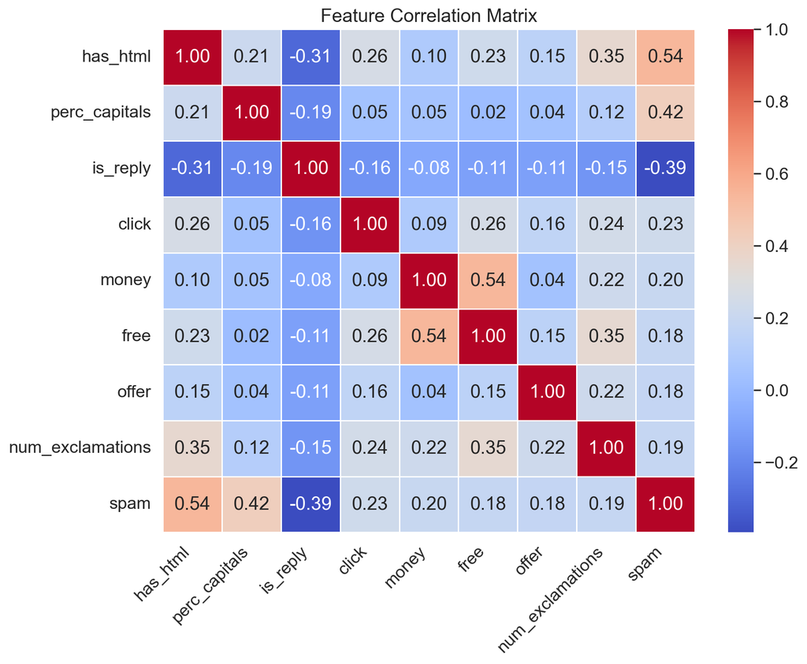

Pairwise Pearson correlations across all engineered features and the spam label.

```python
all_features = selected_features + ['spam']

# Compute features on full training set for a stable heatmap
full_feat = extract_features(train)

corr = full_feat[all_features].corr()

plt.figure(figsize=(10, 8))
sns.heatmap(corr, annot=True, fmt='.2f', cmap='coolwarm', linewidths=0.4)
plt.title('Feature Correlation Matrix')
plt.xticks(rotation=45, ha='right')
plt.tight_layout()
plt.show()
```

## 5. Baseline Model

### 5.1 Five-Word Logistic Regression

The simplest possible classifier uses five words — “drug”, “bank”, “prescription”, “memo”, and “private” — as binary features fed directly into logistic regression.

```python
five_words = ['drug', 'bank', 'prescription', 'memo', 'private']
train_lower = train.copy()
train_lower['email'] = train_lower['email'].str.lower()

X_baseline = words_in_texts(five_words, train_lower['email'])
y_train_base = train['spam'].values

baseline_model = LogisticRegression()
baseline_model.fit(X_baseline, y_train_base)

baseline_train_acc = baseline_model.score(X_baseline, y_train_base)
print(f'Baseline training accuracy: {baseline_train_acc:.3f}')
```

```
Baseline training accuracy: 0.758
```

### 5.2 The Zero Predictor Benchmark

**A critical sanity check for any classifier is comparison against the “zero predictor”** — a trivial model that always predicts legitimate. Because ~74% of emails are legitimate, the zero predictor achieves 74% accuracy while detecting exactly zero spam. Any useful filter must beat this benchmark not just on accuracy, but on recall.

```python
zero_acc = 1 - y_train_base.mean()
print(f'Zero predictor accuracy: {zero_acc:.3f}  (recall = 0.000)')
print(f'Baseline accuracy:       {baseline_train_acc:.3f}')
```

```
Zero predictor accuracy: 0.745  (recall = 0.000)
Baseline accuracy:       0.758
```

### 5.3 Precision, Recall, and False Positive Rate

```python
y_pred_base = baseline_model.predict(X_baseline)

TP = np.sum((y_pred_base == 1) & (y_train_base == 1))
TN = np.sum((y_pred_base == 0) & (y_train_base == 0))
FP = np.sum((y_pred_base == 1) & (y_train_base == 0))
FN = np.sum((y_pred_base == 0) & (y_train_base == 1))

precision = TP / (TP + FP)
recall    = TP / (TP + FN)
fpr       = FP / (FP + TN)

print(f'Precision:          {precision:.3f}')
print(f'Recall:             {recall:.3f}')
print(f'False positive rate:{fpr:.3f}')
print(f'\nTP={TP}, TN={TN}, FP={FP}, FN={FN}')
```

```
Precision:          0.642
Recall:             0.114
False positive rate:0.022

TP=219, TN=5473, FP=122, FN=1699
```

**Warning**

**The baseline model catches very little spam.** With a recall well below 50%, more than half of spam emails land in the inbox undetected. The five chosen words (“drug”, “bank”, etc.) appear in too few emails to provide meaningful signal — most feature rows are all zeros. The model’s modest accuracy edge over the zero predictor comes almost entirely from correctly labeling legitimate emails, not from detecting spam.

## 6. Improved Model

### 6.1 Training

The improved model uses the eight structural and lexical features from Section 4. Features that showed at least moderate correlation with spam in the heatmap were retained; weaker candidates (email length, forward indicator, digit count) were dropped to avoid noise.

```python
X_train = train_feat[selected_features].to_numpy()
y_train = train['spam'].to_numpy()
X_val   = val_feat[selected_features].to_numpy()
y_val   = val['spam'].to_numpy()

model = LogisticRegression(max_iter=1000)
model.fit(X_train, y_train)

train_acc = model.score(X_train, y_train)
val_acc   = model.score(X_val,   y_val)
print(f'Training accuracy:   {train_acc:.3f}')
print(f'Validation accuracy: {val_acc:.3f}')
```

```
Training accuracy:   0.874
Validation accuracy: 0.865
```

### 6.2 Cross-Validation

Ten-fold cross-validation confirms that the validation accuracy generalises — the mean CV score closely matches the held-out validation result, and the standard deviation is small, indicating stable performance across folds.

```python
cv_scores = compute_CV_error(X_train, y_train, folds=10)
print(f'CV accuracy: {np.mean(cv_scores):.3f} ± {np.std(cv_scores):.3f}')
print(f'Fold scores: {[round(s, 3) for s in cv_scores]}')
```

```
CV accuracy: 0.874 ± 0.011
Fold scores: [np.float64(0.884), np.float64(0.872), np.float64(0.875), np.float64(0.887), np.float64(0.866), np.float64(0.888), np.float64(0.87), np.float64(0.863), np.float64(0.854), np.float64(0.88)]
```

### 6.3 Confusion Matrix

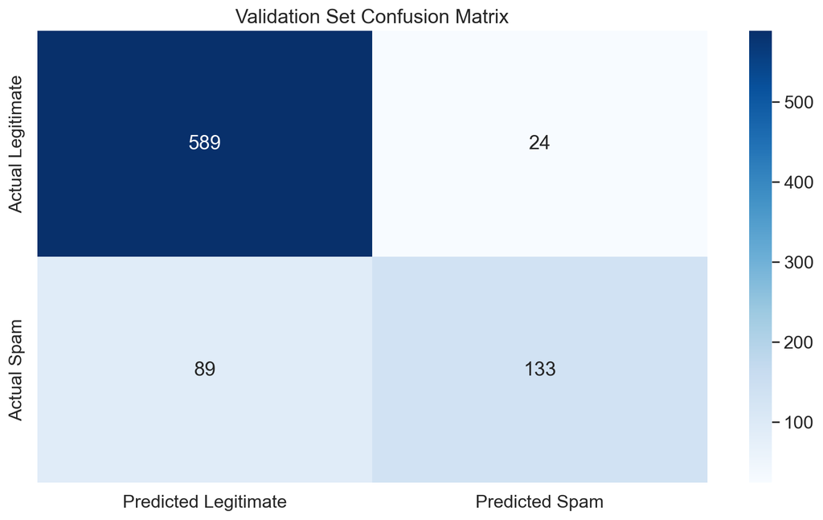

Confusion matrix on the held-out validation set.

```
Validation precision: 0.847
Validation recall:    0.599
Validation FPR:       0.039
```

```python
y_val_pred = model.predict(X_val)
cm = confusion_matrix(y_val, y_val_pred)

sns.heatmap(cm, annot=True, fmt='d', cmap='Blues',
            xticklabels=['Predicted Legitimate', 'Predicted Spam'],
            yticklabels=['Actual Legitimate',    'Actual Spam'])
plt.title('Validation Set Confusion Matrix')
plt.tight_layout()
plt.show()

val_precision = cm[1,1] / (cm[0,1] + cm[1,1])
val_recall    = cm[1,1] / (cm[1,0] + cm[1,1])
val_fpr       = cm[0,1] / (cm[0,0] + cm[0,1])
print(f'Validation precision: {val_precision:.3f}')
print(f'Validation recall:    {val_recall:.3f}')
print(f'Validation FPR:       {val_fpr:.3f}')
```

**Note**

**Compared to the baseline**, the improved model achieves substantially higher recall — it catches the majority of spam while keeping the false positive rate low enough to be practical as an inbox filter.

## 7. Model Analysis

### 7.1 ROC Curve

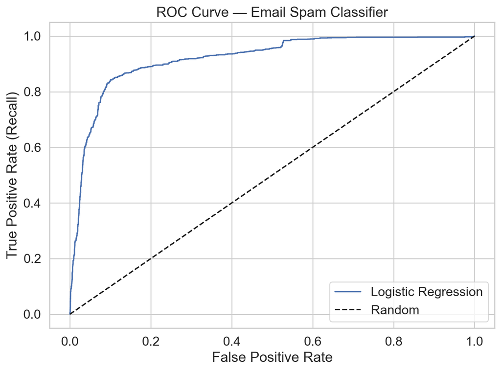

ROC curve on the training set. The diagonal dashed line represents random guessing.

```python
train_probs = model.predict_proba(X_train)[:, 1]
fpr_curve, tpr_curve, _ = roc_curve(y_train, train_probs)

plt.figure(figsize=(8, 6))
plt.plot(fpr_curve, tpr_curve, label='Logistic Regression')
plt.plot([0, 1], [0, 1], 'k--', label='Random')
plt.xlabel('False Positive Rate')
plt.ylabel('True Positive Rate (Recall)')
plt.title('ROC Curve — Email Spam Classifier')
plt.legend()
plt.grid(True)
plt.tight_layout()
plt.show()
```

### 7.2 Feature Coefficients

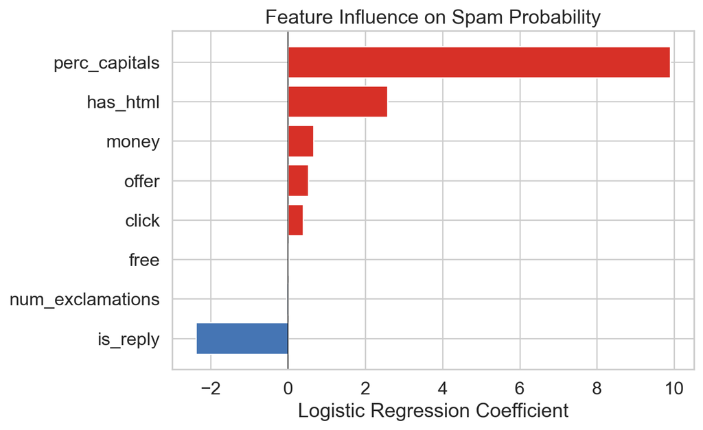

Model coefficients for each feature. Positive values push toward spam, negative toward legitimate.

```python
coef_df = pd.DataFrame({
    'Feature':     selected_features,
    'Coefficient': model.coef_[0]
}).sort_values('Coefficient')

colors = ['#d73027' if c > 0 else '#4575b4' for c in coef_df['Coefficient']]

plt.figure(figsize=(8, 5))
plt.barh(coef_df['Feature'], coef_df['Coefficient'], color=colors)
plt.axvline(0, color='black', linewidth=0.7)
plt.xlabel('Logistic Regression Coefficient')
plt.title('Feature Influence on Spam Probability')
plt.tight_layout()
plt.show()
```

### 7.3 Feature Ablation

```python
some_words = ['drug', 'bank', 'prescription', 'memo', 'private']
train_lower_ab = train.copy()
train_lower_ab['email'] = train_lower_ab['email'].str.lower()
X_ab = words_in_texts(some_words, train_lower_ab['email'])
y_ab = train['spam'].values

ab_model = LogisticRegression()
ab_model.fit(X_ab, y_ab)

# Find a spam email with 3+ features present
idx = next(i for i in range(len(X_ab)) if X_ab[i].sum() >= 3 and y_ab[i] == 1)
feature_to_remove = some_words[np.argmax(X_ab[idx])]

changed_words = [w for w in some_words if w != feature_to_remove]
X_changed = words_in_texts(changed_words, train_lower_ab['email'])
changed_model = LogisticRegression()
changed_model.fit(X_changed, y_ab)

orig_prob    = ab_model.predict_proba(X_ab[[idx]])[:, 1][0]
changed_prob = changed_model.predict_proba(X_changed[[idx]])[:, 1][0]

print(f'Email index: {idx}')
print(f'Feature removed: "{feature_to_remove}"')
print(f'Before: {orig_prob:.1%} spam  →  classified as {"spam" if orig_prob >= 0.5 else "legitimate"}')
print(f'After:  {changed_prob:.1%} spam  →  classified as {"spam" if changed_prob >= 0.5 else "legitimate"}')
```

```
Email index: 19
Feature removed: "drug"
Before: 97.3% spam  →  classified as spam
After:  96.9% spam  →  classified as spam
```

## 8. Ethical Considerations

**Important**

**Key takeaways from working with real-world email data:**

- **Ground truth is not always clear-cut.** Some emails in this dataset are genuinely ambiguous — a newsletter from a known sender, or a promotional email the recipient actually signed up for. Mislabeled training examples introduce irreducible noise that no model tuning can fix.
- **False positives have real costs.** A spam filter that flags too many legitimate emails erodes user trust and can cause important messages to disappear silently. In higher-stakes settings (e.g., content moderation on social platforms), incorrectly removing a post can disenfranchise users and invite regulatory scrutiny.
- **Interpretability matters for accountability.** A model with 8 features can be audited: a user or moderator can see exactly *why* an email was flagged. At 1,000 features, that explanation becomes practically impossible without additional tooling. When automated decisions affect people, interpretability is not a nice-to-have — it is a design requirement.